# Supplementary Information, Usage frequency and lexical class determine the evolution of kinship terms in Indo-European

Rácz, Passmore, Sheard, and Jordan

# 1 Kinship data

We collected kin terms from 45 languages for the following relations: B, D, F, M, MB, MZ, MZD, MZS, S, Z, collected from a combination of native speakers, ethnographies, and dictionaries in our [‘Kinbank’ database](https://excd.org/research-activities/kinbank/). Initially, the analyses used a broader set of kinship terms (e.g. FB, FZ), however we restricted the sample to form a comparable set of word frequencies. This is because most Indo-European languages do not have separate terms for e.g. MZD and MBD and separate terms for e.g. BW are exceedingly rare (both across languages as types and within languages as token). We have not included *husband* and *wife*, because these are often synonymous with *man* and *woman*, respectively.

Frequency data were collected from 34 corpora in 21 languages in three corpus types: spoken, written, and web-crawled. The list of corpora is in Table S1 below.

Table S1: Source of frequency data (source of words is Kinbank)

| Language | Corpus name | Reference |
| --- | --- | --- |
| Albanian | Albanian NC | (Morozova М 2015) |
| Bulgarian | Bulgarian NC | (Koeva, Blagoeva, and Kolkovska 2010) |
| Bulgarian | Bulgarian Web 2012 (bgTenTen12) | (Kilgarriff et al. 2014) |
| Catalan | Catalan Web 2014 (caTenTen14) | (Kilgarriff et al. 2014) |
| English | CELEX | (Baayen, Piepenbrock, and H 1993) |
| German | CELEX | (Baayen, Piepenbrock, and H 1993) |
| Spanish | CoE | (Moreno-Sandoval et al. 2005) |
| Portuguese | CoP | (Craveiro, Macedo, and Madeira 2012) |
| Italian | CORIS | (Favretti, Tamburini, and De Santis 2002) |
| Czech | Czech Web 2012 (czTenTen12 v8) | (Kilgarriff et al. 2014) |
| Danish | Danish Web 2014 (daTenTen14) | (Kilgarriff et al. 2014) |
| Dutch | Dutch Instituut voor Nederlandse Lexicologie text corpora (written) Corpus Gesproken Nederlands (spoken) | (Kruyt and others 1997) |
| Dutch | Dutch Instituut voor Nederlandse Lexicologie text corpora (written) Corpus Gesproken Nederlands (spoken) | (Van Eerten 2007) |
| Dutch | Dutch Web 2014 (nlTenTen14) | (Kilgarriff et al. 2014) |
| French | French Web 2012 (frTenTen12) | (Kilgarriff et al. 2014) |
| German | German Web 2013 (deTenTen13) | (Kilgarriff et al. 2014) |
| Greek | Greek Web 2014 (elTenTen14) | (Kilgarriff et al. 2014) |
| Croatian | hrWaC | (Kilgarriff et al. 2014) |
| Italian | Italian Web 2010 (itTenTen) | (Kilgarriff et al. 2014) |
| French | lexique corpus | (New et al. 2001) |
| Norwegian | Norwegian Web 2015 (noTenTen15) Bokmal and Nynorsk | (Kilgarriff et al. 2014) |
| Polish | Polish NC written PELCRA spoken | (Przepiórkowski et al. 2008) |
| Polish | Polish NC written PELCRA spoken | (Przepiórkowski et al. 2010) |
| Polish | Polish Web 2012 (plTenTen12) | (Kilgarriff et al. 2014) |
| Portuguese | Portuguese Web 2011 (ptTenTen11, Freeling v3) | (Kilgarriff et al. 2014) |
| English | pukWaC (ukWaC parsed with MaltParser) | (Kilgarriff et al. 2014) |
| Romanian | Romanian Web (roWaC) | (Kilgarriff et al. 2014) |
| Romanian | ROMBAC | (Ion et al. 2012) |
| Russian | Russian NC via Leeds | (Lyashevskaya and Sharov 2009) |
| Russian | Russian Web 2011 (ruTenTen11) | (Kilgarriff et al. 2014) |
| Serbian | scWaC | (Kilgarriff et al. 2014) |
| Spanish | Spanish Web 2011 (esTenTen11, Eu + Am, Freeling v4) | (Kilgarriff et al. 2014) |
| Swedish | SUC | (Gustafson-Capková and Hartmann 2006) |
| Swedish | Swedish Web 2014 (svTenTen14) | (Kilgarriff et al. 2014) |
| Icelandic | textasafn | (Úlfarsdóttir and Bjarnadóttir 2017) |
| Czech | UCNK:SYN2015 (written) ORAL2013 (spoken) | (Čermák 1997) |
| Czech | UCNK:SYN2015 (written) ORAL2013 (spoken) | (Benešová, Kren, and Waclawicová 2013) |

The analysis uses one term per language per kinterm. If it arises that a language has multiple words for a particular kinterm, we use which ever was more frequent in the corpus data. In the case where a language has multiple words for a single kinterm, and we do not have access to frequency data, we rely on expert judgement to select a term.

## 1.1 Supplementary data table

See the supplementary data csv file for the raw data used in this study.

#### 1.1.0.1 Column description:

Table S2: Supplementary table column descriptions

[output not shown]

## 1.2 Data summary

We estimate rate of replacement and compare it with frequency of use for ten types of kin relations. Here we use MB, MZ, MZS, and MZD as shorthand for broader terms (uncle, aunt, male cousin, and female cousin, respectively). This is because commonly used terms in this set of languages do not distinguish terms according to the parent’s gender.

Below is a table indicating the shorthand used for each kinterm, the number of languages for which we have data, and the number of states (or cognates) for that term.

We collected terms for a superset of the languages from which frequency data is available in order to have a more robust estimate of rate of replacement for each term.

Table S3: Each kinterm used, with counts for the number of languages we have data for and the number of cognates across our sample

[output not shown]

## 1.3 Frequency data

Below are bar graphs of term frequency by language, across corpora types (web, written, or spoken).

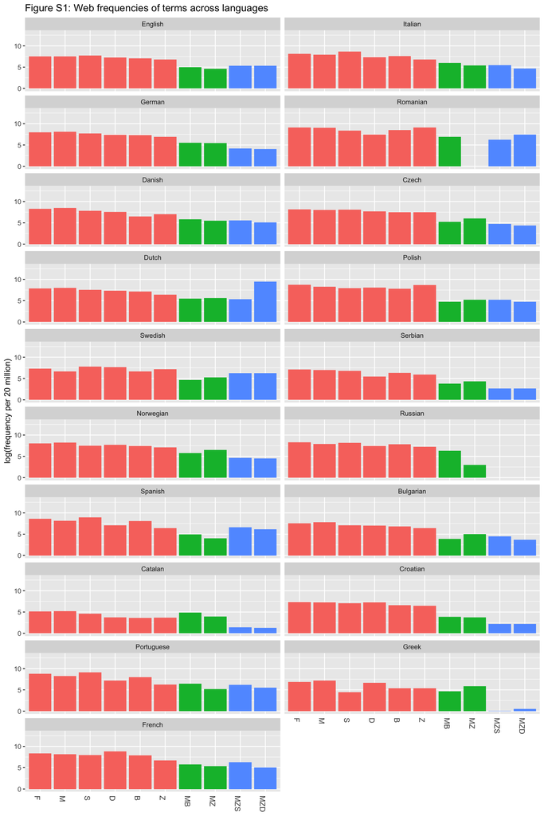

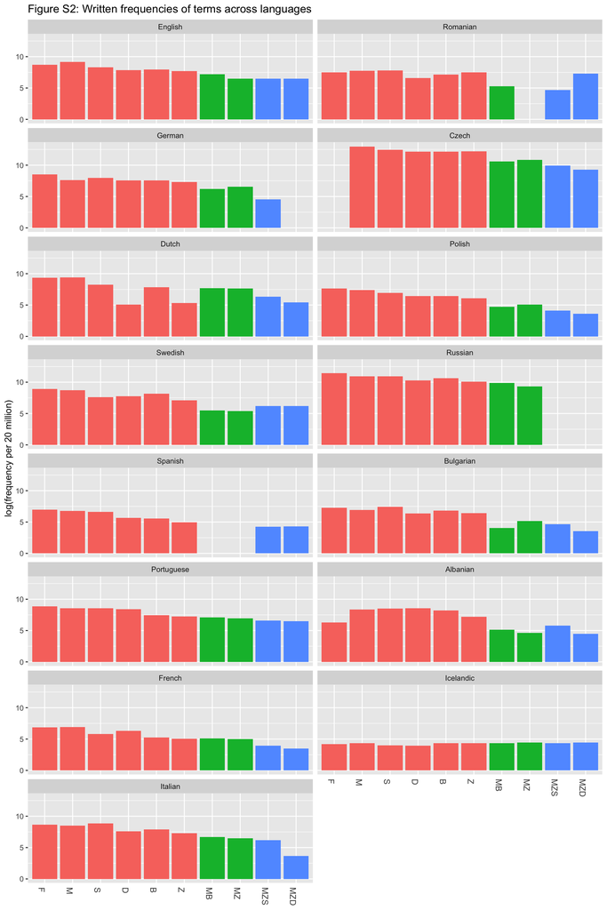

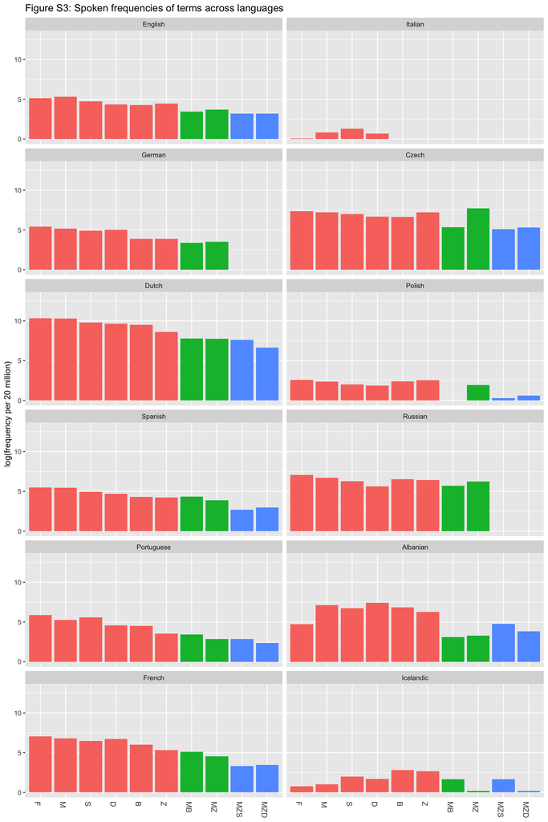

# 2 Cognate data

We generated cognate classes using the Indo-European Etymological Dictionary (Buck 2008), LingPy (List, Greenhill, and Forkel 2018), and a panel of volunteer experts, recruited on Linguist List (all faults remain ours). All terms were automatically transcribed into the Speech Assessment Methods Phonetic Alphabet (SAMPA) through LingPy’s `uni2sampa` function. Cognates were automatically allocated using LingPy’s `cluster` function. Using the cognate-coded Swadesh list (subset to those languages for which we also have kinterms), we tested the appropriateness of edit distance, SCA, and turchin algorithms, alongside Phonemic and Phonetic transcriptions for cognate detection in our data, following the code examples from [Lingpy.org](http://lingpy.org/examples.html). The F-score was highest for the edit-distance algorithm with a 0.4 threshold (see table S4) (List, Greenhill, and Forkel 2018). We then manually adjusted the results, followed by expert review which resulted in minor changes. Automatic decisions and the corrections are available in the supplementary data file.

Table S4: Precision, recall, & F-score for various LingPy cognate detection algorithms and their threshold settings.

| transcription | threshold | method | precision | recall | fscore |
| --- | --- | --- | --- | --- | --- |
| Phonemic | 0.4 | edit | 0.7792 | 0.4238 | 0.5490 |
| Phonemic | 0.6 | edit | 0.6259 | 0.4247 | 0.5060 |
| Phonemic | 0.4 | turchin | 0.5152 | 0.4271 | 0.4670 |
| Phonemic | 0.6 | turchin | 0.5152 | 0.4271 | 0.4670 |
| Phonetic | 0.4 | edit | 0.8434 | 0.3194 | 0.4634 |
| Phonemic | 0.4 | sca | 0.4821 | 0.4273 | 0.4530 |
| Phonemic | 0.6 | edit | 0.6944 | 0.3204 | 0.4385 |
| Romanised | 0.4 | edit | 0.6930 | 0.2948 | 0.4136 |
| Phonetic | 0.4 | turchin | 0.4524 | 0.3213 | 0.3758 |
| Phonetic | 0.6 | turchin | 0.4524 | 0.3213 | 0.3758 |
| Phonetic | 0.6 | turchin | 0.4524 | 0.3213 | 0.3758 |
| Romanised | 0.6 | edit | 0.5079 | 0.2958 | 0.3739 |
| Phonetic | 0.4 | sca | 0.4418 | 0.3221 | 0.3726 |
| Romanised | 0.4 | sca | 0.4491 | 0.2962 | 0.3570 |
| phoneMic | 0.6 | sca | 0.3011 | 0.4294 | 0.3539 |
| Romanised | 0.4 | turchin | 0.4290 | 0.2963 | 0.3505 |
| Romanised | 0.6 | turchin | 0.4290 | 0.2963 | 0.3505 |
| Phonetic | 0.6 | sca | 0.2262 | 0.3244 | 0.2666 |
| Romanised | 0.6 | sca | 0.2227 | 0.2983 | 0.2550 |

## 2.1 Phylogeny

We used 1000 phylogenies from the most recent Bayesian posterior of Indo-European phylogenies (Bouckaert et al. 2012). Trees in the sample are rooted. Branch lengths are given in years and derived from statistical and historical calibration. The Indo-European posterior used has an approximate age of 8,700 years. Trees initially have 111 taxa, and these were pruned down for each kinterm dependent on available data. Counts for taxa for each kinterm can be found in table S3. By using a sample of likely phyloygenies and through using a Bayesian approach, we account for the phylogenetic uncertainty.

## 2.2 Rates of change

Each analysis was run 3 times to ensure the MCMC chain converged. Tables S5 - S14 display the marginal log-likelihood for each MCMC run, the mean global rate of change for each run, and the average across the three runs. For each kinterm, we also used the Gelman-Rubin diagnostic test for convergence (Gelman and Rubin 1992). This tests for MCMC convergence between multiple chains by analysing the differences between them. By estimating a ‘potential scale reduction factor’, which when multiplying across chains would remove the differences, we can quantify the differences between chains (a scale reduction factor 1 indicating no change needed). A rule of thumb suggests a point estimates of less than 1.1 is sufficient to claim convergence, and ensuring upper limits are also around these limits.

Table S5: B

|  | Marginal log-likelihood | Harmonic Mean global rate | Harmonic SD global rate |
| --- | --- | --- | --- |
| 1 | 50.38400 | 0.0001267 | 5e-07 |
| 2 | 47.36400 | 0.0001240 | 4e-07 |
| 3 | 49.74900 | 0.0001219 | 4e-07 |
| Mean | 49.16567 | 0.0001242 | 4e-07 |

Table S6: D

|  | Marginal log-likelihood | Harmonic Mean global rate | Harmonic SD global rate |
| --- | --- | --- | --- |
| 1 | 67.15900 | 0.0002732 | 8e-07 |
| 2 | 66.91900 | 0.0002718 | 8e-07 |
| 3 | 70.64700 | 0.0002704 | 9e-07 |
| Mean | 68.24167 | 0.0002718 | 8e-07 |

Table S7: F

|  | Marginal log-likelihood | Harmonic Mean global rate | Harmonic SD global rate |
| --- | --- | --- | --- |
| 1 | 69.12500 | 0.0002581 | 8e-07 |
| 2 | 71.08600 | 0.0002657 | 9e-07 |
| 3 | 65.72500 | 0.0002615 | 9e-07 |
| Mean | 68.64533 | 0.0002618 | 8e-07 |

Table S8: M

|  | Marginal log-likelihood | Harmonic Mean global rate | Harmonic SD global rate |
| --- | --- | --- | --- |
| 1 | 57.339 | 0.0002995 | 1e-06 |
| 2 | 57.493 | 0.0002999 | 9e-07 |
| 3 | 59.432 | 0.0002995 | 1e-06 |
| Mean | 58.088 | 0.0002996 | 1e-06 |

Table S9: MB

|  | Marginal log-likelihood | Harmonic Mean global rate | Harmonic SD global rate |
| --- | --- | --- | --- |
| 1 | 57.44400 | 0.0003308 | 1.1e-06 |
| 2 | 57.04900 | 0.0003303 | 1.2e-06 |
| 3 | 57.78000 | 0.0003401 | 1.1e-06 |
| Mean | 57.42433 | 0.0003337 | 1.1e-06 |

Table S10: MZ

|  | Marginal log-likelihood | Harmonic Mean global rate | Harmonic SD global rate |
| --- | --- | --- | --- |
| 1 | 74.88300 | 0.0005056 | 1.8e-06 |
| 2 | 73.92900 | 0.0005090 | 1.8e-06 |
| 3 | 68.98400 | 0.0005106 | 1.7e-06 |
| Mean | 72.59867 | 0.0005084 | 1.7e-06 |

Table S11: MZD

|  | Marginal log-likelihood | Harmonic Mean global rate | Harmonic SD global rate |
| --- | --- | --- | --- |
| 1 | 63.392 | 0.0003877 | 1.3e-06 |
| 2 | 58.497 | 0.0003839 | 1.4e-06 |
| 3 | 57.940 | 0.0003916 | 1.3e-06 |
| Mean | 59.943 | 0.0003877 | 1.4e-06 |

Table S12: MZS

|  | Marginal log-likelihood | Harmonic Mean global rate | Harmonic SD global rate |
| --- | --- | --- | --- |
| 1 | 61.62400 | 0.0004162 | 1.3e-06 |
| 2 | 62.33400 | 0.0004158 | 1.3e-06 |
| 3 | 60.83500 | 0.0004151 | 1.4e-06 |
| Mean | 61.59767 | 0.0004157 | 1.4e-06 |

Table S13: S

|  | Marginal log-likelihood | Harmonic Mean global rate | Harmonic SD global rate |
| --- | --- | --- | --- |
| 1 | 47.75800 | 0.0001669 | 7e-07 |
| 2 | 50.56400 | 0.0001666 | 7e-07 |
| 3 | 48.46100 | 0.0001711 | 6e-07 |
| Mean | 48.92767 | 0.0001682 | 7e-07 |

Table S14: Z

|  | Marginal log-likelihood | Harmonic Mean global rate | Harmonic SD global rate |
| --- | --- | --- | --- |
| 1 | 42.31300 | 0.0001205 | 5e-07 |
| 2 | 44.06800 | 0.0001215 | 6e-07 |
| 3 | 44.12300 | 0.0001265 | 5e-07 |
| Mean | 43.50133 | 0.0001229 | 5e-07 |

Table S15: Point estimates and upper 95% confidence limits for Gelman-Rubin MCMC diagnostic tests

|  | Point est. | Upper C.I. |
| --- | --- | --- |
| Table S5: B | 1.00 | 1.01 |
| Table S6: D | 1.00 | 1.00 |
| Table S7: F | 1.00 | 1.01 |
| Table S8: M | 1.00 | 1.00 |
| Table S9: MB | 1.00 | 1.00 |
| Table S10: MZ | 1.01 | 1.02 |
| Table S11: MZD | 1.00 | 1.02 |
| Table S12: MZS | 1.00 | 1.00 |
| Table S13: S | 1.00 | 1.00 |
| Table S14: Z | 1.00 | 1.00 |

## 2.3 *Example BayesTraits script*

```bash
BayesTraitsV3 tree.file data.file
1
2
NQM
Pis Emp
RevJump exp 10
Stones 100 1000
Iterations 10010000
Burnin 10000
Sample 10000
LogFile logs/file
run
```

## 2.4 Half-life

We calculate the half-life of each kinterm following methods from Pagel and Meade (2018). The half-life of a term estimates the expected amount of time before a 50% chance of a cognate change.

Table S16: Mean half-life for each kin code

| Kin code | Half-life (years) |
| --- | --- |
| B | 5471 |
| D | 2537 |
| F | 2686 |
| M | 2315 |
| MB | 2096 |
| MZ | 1371 |
| MZD | 1788 |
| MZS | 1666 |
| S | 4152 |
| Z | 5751 |

# 3 Frequency of use and rates of change: Swadesh words and kin terms

We want to see if

- Rate of change correlates with frequency of use for kin terms
- What the strength of this relationship is compared to Swadesh terms

The difficulty is that the two data sets are structured differently. A given **kin term** can have a written / spoken / web frequency as well as a word / lemma frequency. A given **Swadesh term** only has one frequency (though it may be written / spoken / etc. depending on the source corpus). Term **length** correlates with frequency of use in a way that’s not directly relevant to our analysis either.

In order to create comparable kin- and Swadesh-datasets, we fit a linear mixed model as control on the kinterm data and use word random intercepts from this model in a second, predictive, model.

## 3.1 Control model: kin terms

> Model 1 (M1):

> Centralised log frequency of use per million ~ Corpus genre + Frequency type + (1 | Word meaning)

The aim of M1 is to provide us with a word random intercept that incorporates genre and frequency type information. As a result, random slopes were not tested. Table S17 shows the fixed effects for this model.

Table S17: Summary of fixed effects for control model 1

|  | Estimate | Std. Error | t value |
| --- | --- | --- | --- |
| (Intercept) | -0.54 | 0.21 | -2.56 |
| genreweb | 1.68 | 0.17 | 10.03 |
| genrewritten | 2.61 | 0.18 | 14.58 |
| freq.typeword | -0.74 | 0.13 | -5.50 |

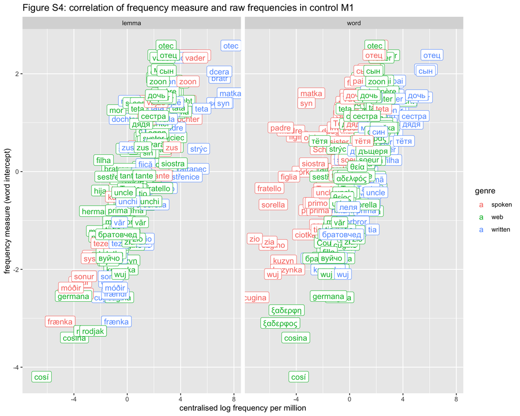

> Model 2 (M2):

> Centralised rate of replacement ~ Frequency measure + Word length + (1 | Language)

Since the frequency measure and word length are both word-level predictors, we have no potential random slopes and report the model with a random intercept for language only. The estimates of the fixed effects can be seen in table S18.

M1 provides us with aggregated information on the centralised log frequency per million of each kinship word. This allows direct comparison with the core vocabulary (where we only have one datum per word) without a considerable loss of information.

M2 only serves to demonstrate that the frequency effect is not an artefact of word length.

Table S18: Summary of fixed effects for control M2

|  | Estimate | Std. Error | t value |
| --- | --- | --- | --- |
| (Intercept) | 0.64 | 0.31 | 2.03 |
| frequency.measure | -0.58 | 0.07 | -8.72 |
| word.length | -0.10 | 0.06 | -1.76 |

## 3.2 Predictive model: rate of change and frequency of use

> Model 3.1 (M3.1):

> Centralised rate of replacement ~ Frequency measure * Word type + (1 | Language)

> Model 3.2 (M3.2):

> Centralised rate of replacement ~ Frequency measure * Word type + (Word type | Language)

The predictive model uses the random word-meaning intercepts (named Frequency measure) from M1 as measures of frequency of use for kin terms, and centralised log frequency per million for the Swadesh terms. We restrict the dataset to languages for which we have kin term data. We propose two possible random effect structures, either random intercepts for each language, or random slopes for each word type in each language. Word-type is the only fixed effect that can vary across language. Goodness-of-fit tests reveal that this random slope results in a better fit (Table S19), so we report the model with the slope (Table S20). The interaction effect is plotted in figure S5. Figure S6 shows a plot of the raw data used in the model, highlighting the kinship terms.

Table S19: Goodness for fit for model random effect structures

[output not shown]

Table S20: Summary of fixed effects for predictive model

|  | Estimate | Std. Error | t value |
| --- | --- | --- | --- |
| (Intercept) | 0.12 | 0.12 | 1.01 |
| frequency.measure | -0.44 | 0.08 | -5.26 |
| word.typeswadesh.word | -0.54 | 0.18 | -2.91 |
| frequency.measure:word.typeswadesh.word | 0.18 | 0.09 | 2.02 |

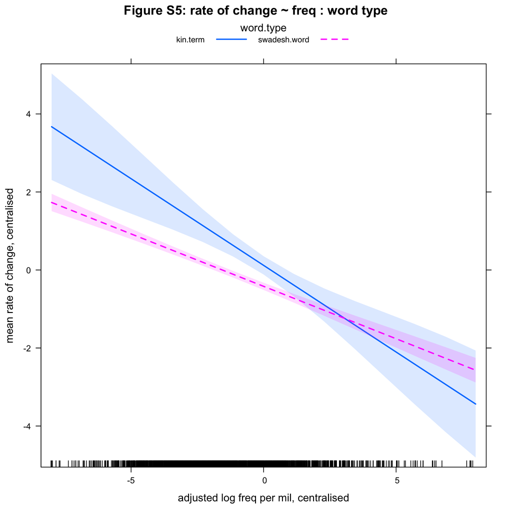

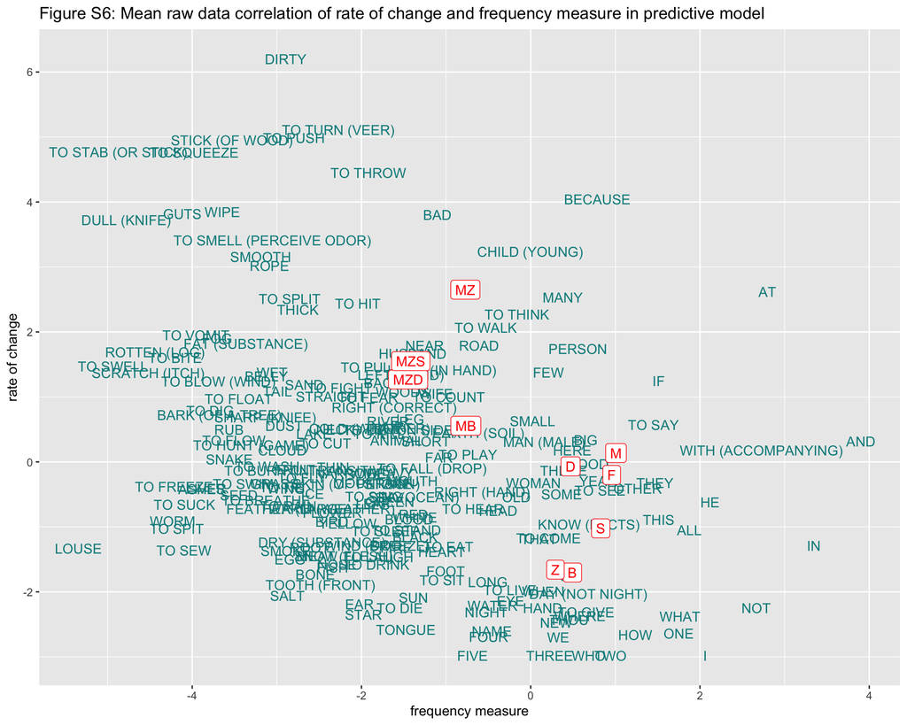

# References

Baayen, R Harald, Richard Piepenbrock, and Rijn van H. 1993. “The $\{$Celex$\}$ Lexical Data Base on $\{$Cd-Rom$\}$.”

Benešová, L, M Kren, and M Waclawicová. 2013. “ORAL2013: Reprezentativnı Korpus Neformálnı Mluvené Ceštiny [Oral2013: A Representative Corpus of Informal Spoken Czech].” *Ustav ˇCeského Národnıho Korpusu FF UK, Praha*.

Bouckaert, Remco, Philippe Lemey, Michael Dunn, Simon J. Greenhill, Alexander V. Alekseyenko, Alexei J. Drummond, Russell D. Gray, Marc A. Suchard, and Quentin D. Atkinson. 2012. “Mapping the Origins and Expansion of the Indo-European Language Family.” *Science* 337 (6097): 957–60. https://doi.org/10.1126/science.1219669.

Buck, Carl Darling. 2008. *A Dictionary of Selected Synonyms in the Principal Indo-European Languages*. University of Chicago Press.

Craveiro, Olga, Joaquim Macedo, and Henrique Madeira. 2012. “It Is the Time for Portuguese Texts!” In *International Conference on Computational Processing of the Portuguese Language*, 106–12. Springer.

Čermák, Franti ek. 1997. “Czech National Corpus: A Case in Many Contexts.” *International Journal of Corpus Linguistics* 2 (2): 181–97.

Favretti, R Rossini, Fabio Tamburini, and Cristiana De Santis. 2002. “CORIS/Codis: A Corpus of Written Italian Based on a Defined and a Dynamic Model.” *A Rainbow of Corpora: Corpus Linguistics and the Languages of the World*, 27–38.

Gelman, Andrew, and Donald B Rubin. 1992. “Inference from Iterative Simulation Using Multiple Sequences.” *Statistical Science*, 457–72.

Gustafson-Capková, Sofia, and Britt Hartmann. 2006. “Manual of the Stockholm Umeå Corpus Version 2.0.” *Stockholm University*.

Ion, Radu, Elena Irimia, Dan Stefanescu, and Dan Tufis. 2012. “ROMBAC: The Romanian Balanced Annotated Corpus.” In *LREC*, 339–44. Citeseer.

Kilgarriff, Adam, Vı́t Baisa, Jan Bušta, Miloš Jakubı́ček, Vojtěch Kovář, Jan Michelfeit, Pavel Rychlỳ, and Vı́t Suchomel. 2014. “The Sketch Engine: Ten Years on.” *Lexicography* 1 (1): 7–36.

Koeva, Svetla, Diana Blagoeva, and Siya Kolkovska. 2010. “Bulgarian National Corpus Project.” *Politics* 207: 2–2.

Kruyt, MWF, and others. 1997. “A 38 Million Words Dutch Text Corpus and Its Users.” *Lexikos* 7 (7): 229–44.

List, Johann-Mattis, Simon J. Greenhill, and Robert Forkel. 2018. “LingPy. A Python Library for Historical Linguistics.” http://lingpy.org.

Lyashevskaya, ON, and SA Sharov. 2009. “Chastotnyj Slovar’sovremennogo Russkogo Iazyka (Na Materialakh Natsionalnogo Korpusa Russkogo Iazyka)[Frequency Dictionary of Modern Russian Based on the Russian National Corpus].” *Moscow: Azbukovnik*.

Moreno-Sandoval, Antonio, Gillermo De la Madrid, Manuel Alcántara, Ana Gonzalez, José Maria Guirao, and Raúl De la Torre. 2005. “The Spanish Corpus.” *C-ORAL-ROM: Integrated Reference Corpora for Spoken Romance Languages, Amsterdam: John Benjamins Publishing Company*, 135–61.

Morozova М, Rusakov А. 2015. “Albanian National Corpus: Composition, Text Processing and Corpus-Oriented Grammar Development.” *Sprache Und Kultur Der Albaner. Zeitliche Und Räumliche Dimensionen.* 5: 270–308.

New, Boris, Christophe Pallier, Ludovic Ferrand, and Rafael Matos. 2001. “Une Base de Données Lexicales Du Français Contemporain Sur Internet: LEXIQUE™//a Lexical Database for Contemporary French: LEXIQUE™.” *L’année Psychologique* 101 (3): 447–62.

Pagel, Mark, and Andrew Meade. 2018. “The Deep History of the Number Words.” *Phil. Trans. R. Soc. B* 373 (1740): 20160517. https://doi.org/10.1098/rstb.2016.0517.

Przepiórkowski, Adam, Rafal L Górski, Marek Lazinski, and Piotr Pezik. 2010. “Recent Developments in the National Corpus of Polish.” In *LREC*.

Przepiórkowski, Adam, Rafal L Górski, Barbara Lewandowska-Tomaszyk, and Marek Lazinski. 2008. “Towards the National Corpus of Polish.” In *LREC*.

Úlfarsdóttir, Thórdı́s, and Kristı́n Bjarnadóttir. 2017. “The Lexicography of Icelandic.” *International Handbook of Modern Lexis and Lexicography*, 1–12.

Van Eerten, Laura. 2007. “Over Het Corpus Gesproken Nederlands.” *Nederlandse Taalkunde* 12 (3): 194–215.